# Project: Investigate a Dataset - (tmdb-movies)

- Introduction
- Data Wrangling
- Exploratory Data Analysis
- Conclusions

## Introduction

### Dataset Description

This data set contains information about 10,000 movies collected from The Movie Database (TMDb), including user ratings and revenue.

● Certain columns, like ‘cast’ and ‘genres’, contain multiple values separated by pipe (|) characters.

● There are some odd characters in the ‘cast’ column. Don’t worry about cleaning them. You can leave them as is.

● The final two columns ending with “_adj” show the budget and revenue of the associated movie in terms of 2010 dollars, accounting for inflation over time.

### Question(s) for Analysis

Which genres are most popular from year to year?

What kinds of properties are associated with movies that have high revenues?

```python
#  import statements for all  of the packages that we plan to use
import numpy as np
import pandas as pd
import matplotlib.pyplot as plt
import seaborn as sns
%matplotlib inline
```

## Data Wrangling

### General Properties

```python
# Load dataframe
df = pd.read_csv('tmdb-movies.csv')
df.head(1)
```

|  | id | imdb_id | popularity | budget | revenue | original_title | cast | homepage | director | tagline | ... | overview | runtime | genres | production_companies | release_date | vote_count | vote_average | release_year | budget_adj | revenue_adj |
| --- | --- | --- | --- | --- | --- | --- | --- | --- | --- | --- | --- | --- | --- | --- | --- | --- | --- | --- | --- | --- | --- |
| 0 | 135397 | tt0369610 | 32.985763 | 150000000 | 1513528810 | Jurassic World | Chris Pratt\|Bryce Dallas Howard\|Irrfan Khan\|Vi... | http://www.jurassicworld.com/ | Colin Trevorrow | The park is open. | ... | Twenty-two years after the events of Jurassic ... | 124 | Action\|Adventure\|Science Fiction\|Thriller | Universal Studios\|Amblin Entertainment\|Legenda... | 6/9/15 | 5562 | 6.5 | 2015 | 1.379999e+08 | 1.392446e+09 |

1 rows × 21 columns

```python
df.shape
```

```
(10866, 21)
```

```python
df.describe()
```

|  | id | popularity | budget | revenue | runtime | vote_count | vote_average | release_year | budget_adj | revenue_adj |
| --- | --- | --- | --- | --- | --- | --- | --- | --- | --- | --- |
| count | 10866.000000 | 10866.000000 | 1.086600e+04 | 1.086600e+04 | 10866.000000 | 10866.000000 | 10866.000000 | 10866.000000 | 1.086600e+04 | 1.086600e+04 |
| mean | 66064.177434 | 0.646441 | 1.462570e+07 | 3.982332e+07 | 102.070863 | 217.389748 | 5.974922 | 2001.322658 | 1.755104e+07 | 5.136436e+07 |
| std | 92130.136561 | 1.000185 | 3.091321e+07 | 1.170035e+08 | 31.381405 | 575.619058 | 0.935142 | 12.812941 | 3.430616e+07 | 1.446325e+08 |
| min | 5.000000 | 0.000065 | 0.000000e+00 | 0.000000e+00 | 0.000000 | 10.000000 | 1.500000 | 1960.000000 | 0.000000e+00 | 0.000000e+00 |
| 25% | 10596.250000 | 0.207583 | 0.000000e+00 | 0.000000e+00 | 90.000000 | 17.000000 | 5.400000 | 1995.000000 | 0.000000e+00 | 0.000000e+00 |
| 50% | 20669.000000 | 0.383856 | 0.000000e+00 | 0.000000e+00 | 99.000000 | 38.000000 | 6.000000 | 2006.000000 | 0.000000e+00 | 0.000000e+00 |
| 75% | 75610.000000 | 0.713817 | 1.500000e+07 | 2.400000e+07 | 111.000000 | 145.750000 | 6.600000 | 2011.000000 | 2.085325e+07 | 3.369710e+07 |
| max | 417859.000000 | 32.985763 | 4.250000e+08 | 2.781506e+09 | 900.000000 | 9767.000000 | 9.200000 | 2015.000000 | 4.250000e+08 | 2.827124e+09 |

```python
df.info()
```

```
<class 'pandas.core.frame.DataFrame'>
RangeIndex: 10866 entries, 0 to 10865
Data columns (total 21 columns):
 #   Column                Non-Null Count  Dtype
---  ------                --------------  -----
 0   id                    10866 non-null  int64
 1   imdb_id               10856 non-null  object
 2   popularity            10866 non-null  float64
 3   budget                10866 non-null  int64
 4   revenue               10866 non-null  int64
 5   original_title        10866 non-null  object
 6   cast                  10790 non-null  object
 7   homepage              2936 non-null   object
 8   director              10822 non-null  object
 9   tagline               8042 non-null   object
 10  keywords              9373 non-null   object
 11  overview              10862 non-null  object
 12  runtime               10866 non-null  int64
 13  genres                10843 non-null  object
 14  production_companies  9836 non-null   object
 15  release_date          10866 non-null  object
 16  vote_count            10866 non-null  int64
 17  vote_average          10866 non-null  float64
 18  release_year          10866 non-null  int64
 19  budget_adj            10866 non-null  float64
 20  revenue_adj           10866 non-null  float64
dtypes: float64(4), int64(6), object(11)
memory usage: 1.7+ MB
```

### Data Cleaning

cleaninig data

```python
# drop unneccessary columns
df.drop(['release_date', 'overview', 'homepage', 'imdb_id', 'tagline', 'budget_adj', 'revenue_adj'], axis = 1, inplace = True)
df.head(1)
```

|  | id | popularity | budget | revenue | original_title | cast | director | keywords | runtime | genres | production_companies | vote_count | vote_average | release_year |
| --- | --- | --- | --- | --- | --- | --- | --- | --- | --- | --- | --- | --- | --- | --- |
| 0 | 135397 | 32.985763 | 150000000 | 1513528810 | Jurassic World | Chris Pratt\|Bryce Dallas Howard\|Irrfan Khan\|Vi... | Colin Trevorrow | monster\|dna\|tyrannosaurus rex\|velociraptor\|island | 124 | Action\|Adventure\|Science Fiction\|Thriller | Universal Studios\|Amblin Entertainment\|Legenda... | 5562 | 6.5 | 2015 |

```python
df.drop('keywords',axis=1,inplace=True)
```

```python
df.head(1)
```

|  | id | popularity | budget | revenue | original_title | cast | director | runtime | genres | production_companies | vote_count | vote_average | release_year |
| --- | --- | --- | --- | --- | --- | --- | --- | --- | --- | --- | --- | --- | --- |
| 0 | 135397 | 32.985763 | 150000000 | 1513528810 | Jurassic World | Chris Pratt\|Bryce Dallas Howard\|Irrfan Khan\|Vi... | Colin Trevorrow | 124 | Action\|Adventure\|Science Fiction\|Thriller | Universal Studios\|Amblin Entertainment\|Legenda... | 5562 | 6.5 | 2015 |

```python
# search for duplicated values
df[df.duplicated()]
```

|  | id | popularity | budget | revenue | original_title | cast | director | runtime | genres | production_companies | vote_count | vote_average | release_year |
| --- | --- | --- | --- | --- | --- | --- | --- | --- | --- | --- | --- | --- | --- |
| 2090 | 42194 | 0.59643 | 30000000 | 967000 | TEKKEN | Jon Foo\|Kelly Overton\|Cary-Hiroyuki Tagawa\|Ian... | Dwight H. Little | 92 | Crime\|Drama\|Action\|Thriller\|Science Fiction | Namco\|Light Song Films | 110 | 5.0 | 2010 |

```python
# drop duplicated
df.drop_duplicates(inplace = True)
```

```python
df.duplicated().sum()
```

```
0
```

Dropped duplicated values

```python
# searching null values
df.isna().sum()
```

```
id                         0
popularity                 0
budget                     0
revenue                    0
original_title             0
cast                      76
director                  44
runtime                    0
genres                    23
production_companies    1030
vote_count                 0
vote_average               0
release_year               0
dtype: int64
```

```python
# drop null values
df.dropna(inplace = True)
```

```python
df.isna().sum()
```

```
id                      0
popularity              0
budget                  0
revenue                 0
original_title          0
cast                    0
director                0
runtime                 0
genres                  0
production_companies    0
vote_count              0
vote_average            0
release_year            0
dtype: int64
```

Dropped NaN values

```python
df.info()
```

```
<class 'pandas.core.frame.DataFrame'>
Int64Index: 9772 entries, 0 to 10865
Data columns (total 13 columns):
 #   Column                Non-Null Count  Dtype
---  ------                --------------  -----
 0   id                    9772 non-null   int64
 1   popularity            9772 non-null   float64
 2   budget                9772 non-null   int64
 3   revenue               9772 non-null   int64
 4   original_title        9772 non-null   object
 5   cast                  9772 non-null   object
 6   director              9772 non-null   object
 7   runtime               9772 non-null   int64
 8   genres                9772 non-null   object
 9   production_companies  9772 non-null   object
 10  vote_count            9772 non-null   int64
 11  vote_average          9772 non-null   float64
 12  release_year          9772 non-null   int64
dtypes: float64(2), int64(6), object(5)
memory usage: 1.0+ MB
```

```python
df.shape
```

```
(9772, 13)
```

```python
df.describe()
```

|  | id | popularity | budget | revenue | runtime | vote_count | vote_average | release_year |
| --- | --- | --- | --- | --- | --- | --- | --- | --- |
| count | 9772.000000 | 9772.000000 | 9.772000e+03 | 9.772000e+03 | 9772.000000 | 9772.000000 | 9772.000000 | 9772.000000 |
| mean | 63189.640810 | 0.694721 | 1.617967e+07 | 4.423121e+07 | 102.926627 | 239.312014 | 5.963528 | 2000.878428 |
| std | 90718.059987 | 1.036931 | 3.221074e+07 | 1.225889e+08 | 27.877432 | 603.011504 | 0.913174 | 13.036794 |
| min | 5.000000 | 0.000188 | 0.000000e+00 | 0.000000e+00 | 0.000000 | 10.000000 | 1.500000 | 1960.000000 |
| 25% | 10221.500000 | 0.232710 | 0.000000e+00 | 0.000000e+00 | 90.000000 | 18.000000 | 5.400000 | 1994.000000 |
| 50% | 18677.500000 | 0.419762 | 2.000000e+05 | 0.000000e+00 | 100.000000 | 46.000000 | 6.000000 | 2005.000000 |
| 75% | 70577.250000 | 0.776408 | 1.928750e+07 | 3.104729e+07 | 112.000000 | 173.000000 | 6.600000 | 2011.000000 |
| max | 417859.000000 | 32.985763 | 4.250000e+08 | 2.781506e+09 | 877.000000 | 9767.000000 | 8.700000 | 2015.000000 |

## Exploratory Data Analysis

### Research Question 1 (Which genres are most popular from year to year?)

```python
df['genres'].unique()
```

```
array(['Action|Adventure|Science Fiction|Thriller',
       'Adventure|Science Fiction|Thriller',
       'Action|Adventure|Science Fiction|Fantasy', ...,
       'Adventure|Drama|Action|Family|Foreign',
       'Comedy|Family|Mystery|Romance',
       'Mystery|Science Fiction|Thriller|Drama'], dtype=object)
```

```python
# extract genres of movies
df_genres = df['genres'].str.get_dummies(sep ='|')
df_genres
```

|  | Action | Adventure | Animation | Comedy | Crime | Documentary | Drama | Family | Fantasy | Foreign | History | Horror | Music | Mystery | Romance | Science Fiction | TV Movie | Thriller | War | Western |
| --- | --- | --- | --- | --- | --- | --- | --- | --- | --- | --- | --- | --- | --- | --- | --- | --- | --- | --- | --- | --- |
| 0 | 1 | 1 | 0 | 0 | 0 | 0 | 0 | 0 | 0 | 0 | 0 | 0 | 0 | 0 | 0 | 1 | 0 | 1 | 0 | 0 |
| 1 | 1 | 1 | 0 | 0 | 0 | 0 | 0 | 0 | 0 | 0 | 0 | 0 | 0 | 0 | 0 | 1 | 0 | 1 | 0 | 0 |
| 2 | 0 | 1 | 0 | 0 | 0 | 0 | 0 | 0 | 0 | 0 | 0 | 0 | 0 | 0 | 0 | 1 | 0 | 1 | 0 | 0 |
| 3 | 1 | 1 | 0 | 0 | 0 | 0 | 0 | 0 | 1 | 0 | 0 | 0 | 0 | 0 | 0 | 1 | 0 | 0 | 0 | 0 |
| 4 | 1 | 0 | 0 | 0 | 1 | 0 | 0 | 0 | 0 | 0 | 0 | 0 | 0 | 0 | 0 | 0 | 0 | 1 | 0 | 0 |
| ... | ... | ... | ... | ... | ... | ... | ... | ... | ... | ... | ... | ... | ... | ... | ... | ... | ... | ... | ... | ... |
| 10861 | 0 | 0 | 0 | 0 | 0 | 1 | 0 | 0 | 0 | 0 | 0 | 0 | 0 | 0 | 0 | 0 | 0 | 0 | 0 | 0 |
| 10862 | 1 | 1 | 0 | 0 | 0 | 0 | 1 | 0 | 0 | 0 | 0 | 0 | 0 | 0 | 0 | 0 | 0 | 0 | 0 | 0 |
| 10863 | 0 | 0 | 0 | 1 | 0 | 0 | 0 | 0 | 0 | 0 | 0 | 0 | 0 | 1 | 0 | 0 | 0 | 0 | 0 | 0 |
| 10864 | 1 | 0 | 0 | 1 | 0 | 0 | 0 | 0 | 0 | 0 | 0 | 0 | 0 | 0 | 0 | 0 | 0 | 0 | 0 | 0 |
| 10865 | 0 | 0 | 0 | 0 | 0 | 0 | 0 | 0 | 0 | 0 | 0 | 1 | 0 | 0 | 0 | 0 | 0 | 0 | 0 | 0 |

9772 rows × 20 columns

```python
# the most popular genres
df_genres_sum =df_genres.sum()
df_genres_sum
```

```
Action             2235
Adventure          1384
Animation           617
Comedy             3433
Crime              1299
Documentary         317
Drama              4364
Family             1095
Fantasy             840
Foreign             120
History             306
Horror             1526
Music               339
Mystery             773
Romance            1570
Science Fiction    1136
TV Movie            132
Thriller           2746
War                 258
Western             160
dtype: int64
```

```python
sorted_genres = df_genres.sum().reset_index()
sorted_genres.sort_values(by = 0,ascending = False)
```

|  | index | 0 |
| --- | --- | --- |
| 6 | Drama | 4364 |
| 3 | Comedy | 3433 |
| 17 | Thriller | 2746 |
| 0 | Action | 2235 |
| 14 | Romance | 1570 |
| 11 | Horror | 1526 |
| 1 | Adventure | 1384 |
| 4 | Crime | 1299 |
| 15 | Science Fiction | 1136 |
| 7 | Family | 1095 |
| 8 | Fantasy | 840 |
| 13 | Mystery | 773 |
| 2 | Animation | 617 |
| 12 | Music | 339 |
| 5 | Documentary | 317 |
| 10 | History | 306 |
| 18 | War | 258 |
| 19 | Western | 160 |
| 16 | TV Movie | 132 |
| 9 | Foreign | 120 |

bar plot of genres over years

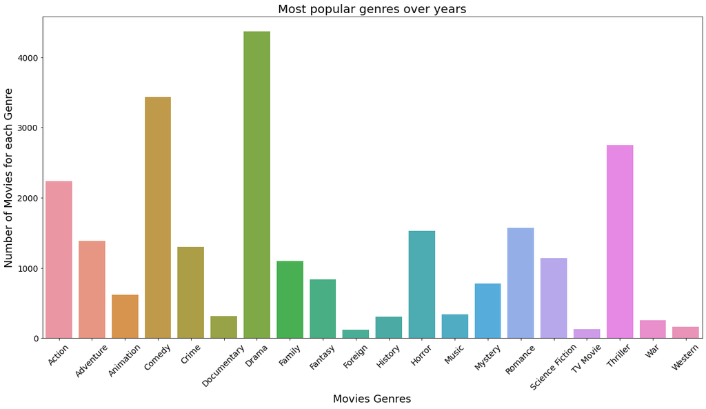

```python
plt.figure(figsize=(20,10))
sns.barplot(x = df_genres.columns, y = df_genres.sum(), data = sorted_genres)
plt.title('Most popular genres over years', fontsize=20)
plt.xlabel('Movies Genres', fontsize=18)
plt.ylabel('Number of Movies for each Genre', fontsize=18)
plt.xticks(rotation = 45, fontsize = 14)
plt.yticks(fontsize=14)
plt.show()
```

### Research Question 2 (What kinds of properties are associated with movies that have high revenues?)

```python
# focus on revenue
sorted_revenue = df.sort_values(by = 'revenue',ascending = False)

sorted_revenue.head(10)
```

|  | id | popularity | budget | revenue | original_title | cast | director | runtime | genres | production_companies | vote_count | vote_average | release_year |
| --- | --- | --- | --- | --- | --- | --- | --- | --- | --- | --- | --- | --- | --- |
| 1386 | 19995 | 9.432768 | 237000000 | 2781505847 | Avatar | Sam Worthington\|Zoe Saldana\|Sigourney Weaver\|S... | James Cameron | 162 | Action\|Adventure\|Fantasy\|Science Fiction | Ingenious Film Partners\|Twentieth Century Fox ... | 8458 | 7.1 | 2009 |
| 3 | 140607 | 11.173104 | 200000000 | 2068178225 | Star Wars: The Force Awakens | Harrison Ford\|Mark Hamill\|Carrie Fisher\|Adam D... | J.J. Abrams | 136 | Action\|Adventure\|Science Fiction\|Fantasy | Lucasfilm\|Truenorth Productions\|Bad Robot | 5292 | 7.5 | 2015 |
| 5231 | 597 | 4.355219 | 200000000 | 1845034188 | Titanic | Kate Winslet\|Leonardo DiCaprio\|Frances Fisher\|... | James Cameron | 194 | Drama\|Romance\|Thriller | Paramount Pictures\|Twentieth Century Fox Film ... | 4654 | 7.3 | 1997 |
| 4361 | 24428 | 7.637767 | 220000000 | 1519557910 | The Avengers | Robert Downey Jr.\|Chris Evans\|Mark Ruffalo\|Chr... | Joss Whedon | 143 | Science Fiction\|Action\|Adventure | Marvel Studios | 8903 | 7.3 | 2012 |
| 0 | 135397 | 32.985763 | 150000000 | 1513528810 | Jurassic World | Chris Pratt\|Bryce Dallas Howard\|Irrfan Khan\|Vi... | Colin Trevorrow | 124 | Action\|Adventure\|Science Fiction\|Thriller | Universal Studios\|Amblin Entertainment\|Legenda... | 5562 | 6.5 | 2015 |
| 4 | 168259 | 9.335014 | 190000000 | 1506249360 | Furious 7 | Vin Diesel\|Paul Walker\|Jason Statham\|Michelle ... | James Wan | 137 | Action\|Crime\|Thriller | Universal Pictures\|Original Film\|Media Rights ... | 2947 | 7.3 | 2015 |
| 14 | 99861 | 5.944927 | 280000000 | 1405035767 | Avengers: Age of Ultron | Robert Downey Jr.\|Chris Hemsworth\|Mark Ruffalo... | Joss Whedon | 141 | Action\|Adventure\|Science Fiction | Marvel Studios\|Prime Focus\|Revolution Sun Studios | 4304 | 7.4 | 2015 |
| 3374 | 12445 | 5.711315 | 125000000 | 1327817822 | Harry Potter and the Deathly Hallows: Part 2 | Daniel Radcliffe\|Rupert Grint\|Emma Watson\|Alan... | David Yates | 130 | Adventure\|Family\|Fantasy | Warner Bros.\|Heyday Films\|Moving Picture Compa... | 3750 | 7.7 | 2011 |
| 5422 | 109445 | 6.112766 | 150000000 | 1274219009 | Frozen | Kristen Bell\|Idina Menzel\|Jonathan Groff\|Josh ... | Chris Buck\|Jennifer Lee | 102 | Animation\|Adventure\|Family | Walt Disney Pictures\|Walt Disney Animation Stu... | 3369 | 7.5 | 2013 |
| 5425 | 68721 | 4.946136 | 200000000 | 1215439994 | Iron Man 3 | Robert Downey Jr.\|Gwyneth Paltrow\|Guy Pearce\|D... | Shane Black | 130 | Action\|Adventure\|Science Fiction | Marvel Studios | 6882 | 6.9 | 2013 |

a heatmap for the correlation of dataset

```python
sr_crr = sorted_revenue.corr()
```

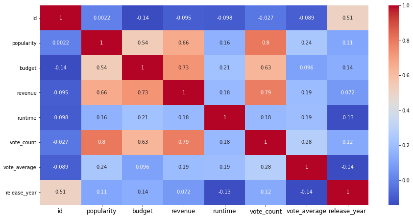

```python
plt.figure(figsize=(15,7.5))
sns.heatmap(sr_crr,cmap = 'coolwarm', annot = True)
plt.xticks(fontsize = 12)
plt.show()
```

Search the correlation between director and revenue

```python
dir_rev = sorted_revenue[['revenue','director']].head(10)
dir_rev
```

|  | revenue | director |
| --- | --- | --- |
| 1386 | 2781505847 | James Cameron |
| 3 | 2068178225 | J.J. Abrams |
| 5231 | 1845034188 | James Cameron |
| 4361 | 1519557910 | Joss Whedon |
| 0 | 1513528810 | Colin Trevorrow |
| 4 | 1506249360 | James Wan |
| 14 | 1405035767 | Joss Whedon |
| 3374 | 1327817822 | David Yates |
| 5422 | 1274219009 | Chris Buck\|Jennifer Lee |
| 5425 | 1215439994 | Shane Black |

bar plot about the higher directors movies revenue

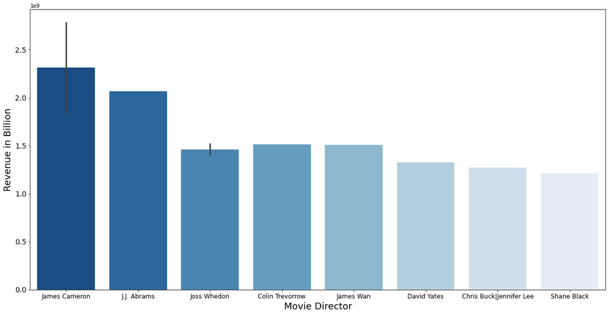

```python
plt.figure(figsize = (20,10))
sns.barplot(x='director', y = 'revenue', data = dir_rev, palette='Blues_r')
plt.xlabel('Movie Director', fontsize=18)
plt.ylabel('Revenue in Billion', fontsize=18)
plt.xticks(fontsize=12)
plt.yticks(fontsize=14)
plt.show()
```

top 10 directors

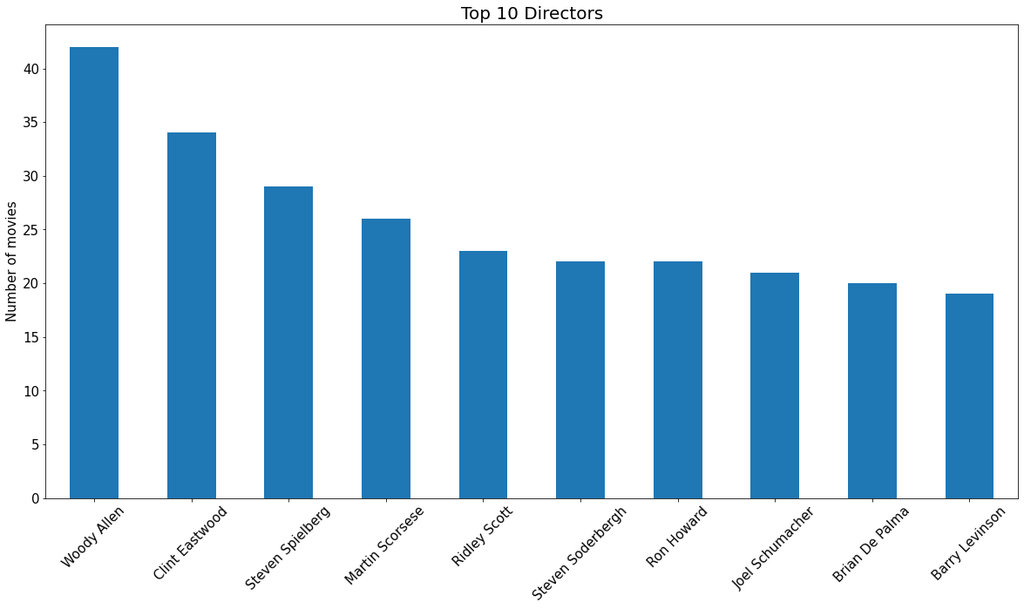

```python
df['director'].value_counts().head(10).plot.bar(figsize=(20,10));
plt.title('Top 10 Directors',fontsize=20)
plt.ylabel('Number of movies',fontsize=15)
plt.xticks(rotation = 45,fontsize=15)
plt.yticks(fontsize=15);
```

bar plot for top 10 movies revenue and its genres

```python
mo_rev = sorted_revenue[['original_title', 'revenue','genres']].head(10)
mo_rev
```

|  | original_title | revenue | genres |
| --- | --- | --- | --- |
| 1386 | Avatar | 2781505847 | Action\|Adventure\|Fantasy\|Science Fiction |
| 3 | Star Wars: The Force Awakens | 2068178225 | Action\|Adventure\|Science Fiction\|Fantasy |
| 5231 | Titanic | 1845034188 | Drama\|Romance\|Thriller |
| 4361 | The Avengers | 1519557910 | Science Fiction\|Action\|Adventure |
| 0 | Jurassic World | 1513528810 | Action\|Adventure\|Science Fiction\|Thriller |
| 4 | Furious 7 | 1506249360 | Action\|Crime\|Thriller |
| 14 | Avengers: Age of Ultron | 1405035767 | Action\|Adventure\|Science Fiction |
| 3374 | Harry Potter and the Deathly Hallows: Part 2 | 1327817822 | Adventure\|Family\|Fantasy |
| 5422 | Frozen | 1274219009 | Animation\|Adventure\|Family |
| 5425 | Iron Man 3 | 1215439994 | Action\|Adventure\|Science Fiction |

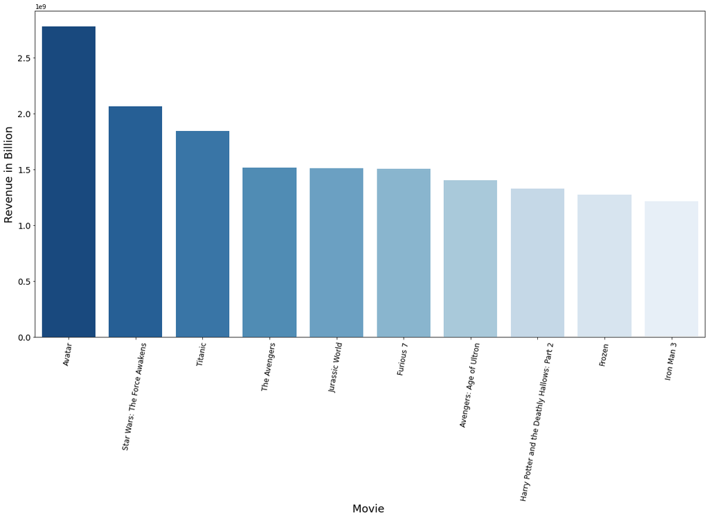

```python
plt.figure(figsize = (20,10))
sns.barplot(x='original_title', y = 'revenue', data = mo_rev, palette='Blues_r')
plt.xlabel('Movie ', fontsize=18)
plt.ylabel('Revenue in Billion', fontsize=18)
plt.xticks(rotation =80,fontsize=12)
plt.yticks(fontsize=14)
plt.show()
```

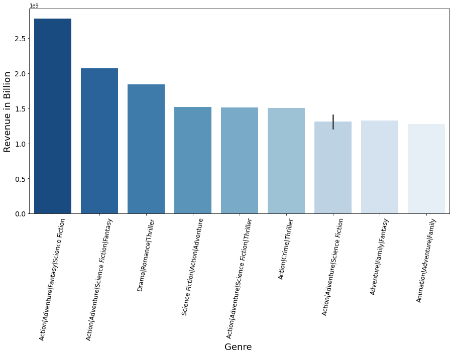

```python
plt.figure(figsize = (15,7.5))
sns.barplot(x='genres', y = 'revenue', data = mo_rev, palette='Blues_r')
plt.xlabel('Genre ', fontsize=18)
plt.ylabel('Revenue in Billion', fontsize=18)
plt.xticks(rotation =80,fontsize=12)
plt.yticks(fontsize=14)
plt.show()
```

number of movies produced per year

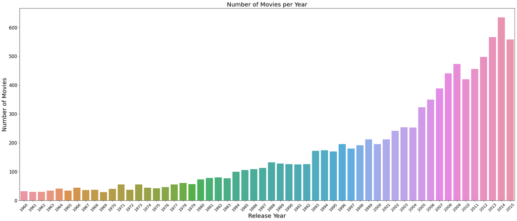

```python
plt.figure(figsize=(30,12))
sns.countplot(x=df['release_year'])
plt.title('Number of Movies per Year', fontsize=20)
plt.xlabel('Release Year',fontsize=20)
plt.ylabel('Number of Movies', fontsize=20)
plt.xticks(rotation=45,fontsize=13)
plt.yticks(fontsize=15)

plt.show()
```

## Conclusions

*Which genres are most popular from year to year

- from the dataset we found that we have about 20 different of genres through years the most popular genres is showed to us by th visualize plot is :

  ```
        1st Darama, 2nd Comedy, 3rd Thriller and 4th is the Action genre
  ```

*What kinds of properties are associated with movies that have high revenues?

we searched for several things and found that:

```
    the high revenue related to some directors thier movies achived high revenue
```

regardless number of movies has been directed we found "James Cameron" have the most high revenue

and another thing that some of genres have high revenue: like action, adventure, fantasy, science fiction, Drama and the movies with high revenue related to thats genres (avater, Titanic, Avengers)

the number of movies per year increased per years and the most year recorded high rank is "2014"

```python
from subprocess import call
call(['python', '-m', 'nbconvert', 'Investigate_a_Dataset.ipynb'])
```

```
1
```